# Thoughts on Experimental Design and Reproducible Research

2017-04-26

## Scientific Method

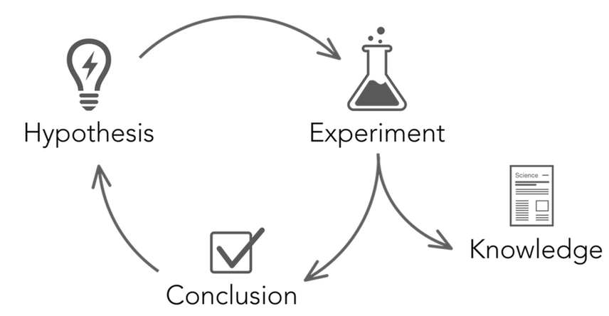

http://blog.findingsapp.com/posts/what-is-an-experiment.html

## Scientific Method

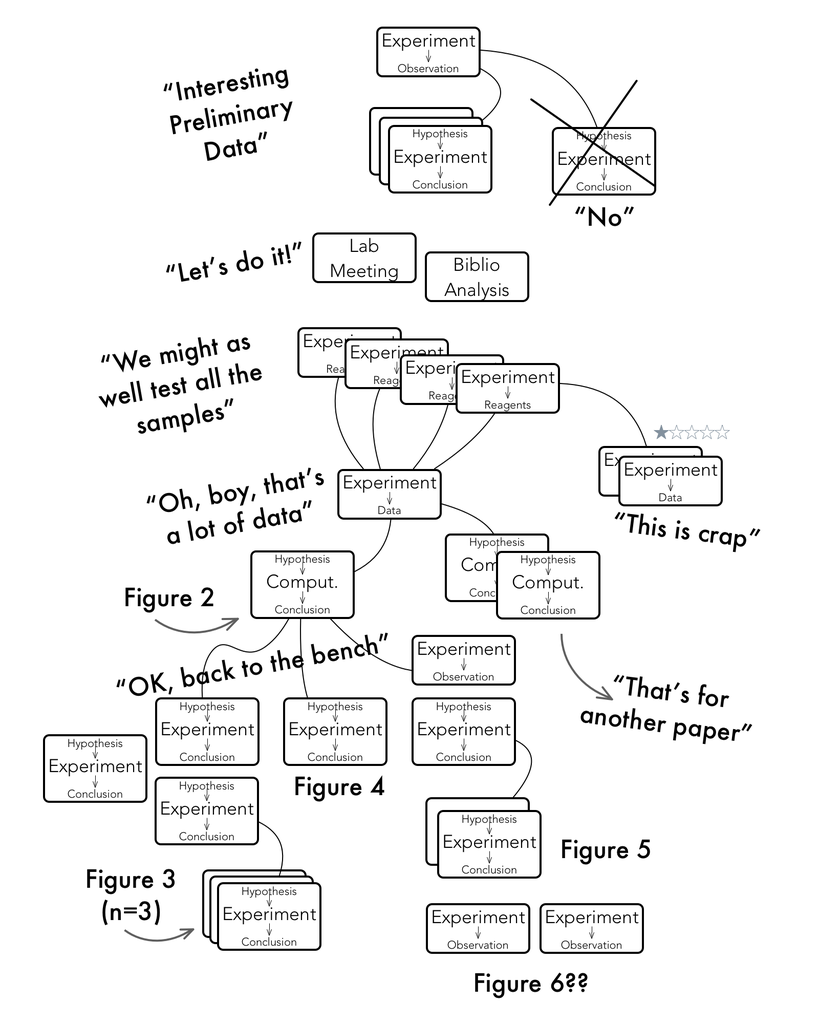

## Deciding on an Experimental Question

## Ethical Considerations

Ethical considerations are integral to the initiation, conduct, and publication of experimental results. In terms of experimental design, consider the following *3Rs* (Fry 2014).

- Replacement
- Refinement
- Reduction

## Ethical Considerations

### Replacement

Does the experiment need to be performed at all or performed as envisioned?

- Literature review
  - Has the study already been done?
  - What designs have been used or proposed for similar experiments in the past?
- Are the experimental materials appropriate for the questions at hand?
  - Cell lines useful instead of animals
  - Low cost tech instead of high cost (PCR vs. Sequencing)

## Ethical Considerations

### Refinement

Does the experiment as envisioned gather appropriate data, have defined stopping rules, standard procedures, and clarity on sources of variability?

- Define important data to gather.
  - Dependent variables and independent variables may not be enough.
  - Consider confounders, technical details, ambient conditions, and metadata (date, time, machine, experimenter, etc.).
- Define when an experiment is "complete".
- Establish standard procedures as clearly as possible.
- Define, to the extent possible, sources of variability and reliability in your approach.

## Ethical Considerations

### Reduction (or is the experiment right-sized)

Can the experiment provide reasonable results with the resources proposed?

- Is sample size appropriate?
- Are resources allocated appropriately?
- Are data sources not directly produced by the experiment included?
- Meta-analysis appropriate?

## Why design?

- To obtain valid results *from which safe and meaningful conclusions can be drawn*
- To know the extent to which results can be generalized
- To use resources efficiently
  - Overpowering (using more than required resources) and, to a greater extent, underpowering can be very costly.

## Hypothesis testing

## The Normal distribution

```r
x = rnorm(10)
mean(x)
```

```
## [1] 0.06730707
```

```r
sum(x)/length(x)
```

```
## [1] 0.06730707
```

```r
sd(x)
```

```
## [1] 1.11168
```

## The Normal Distribution

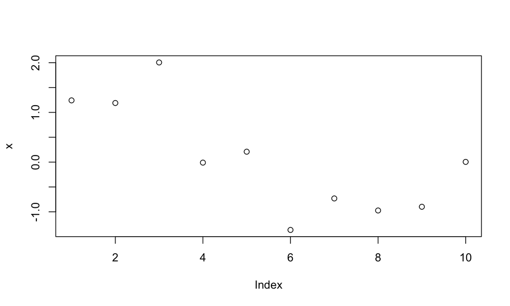

```r
plot(x)
```

## The Normal Distribution

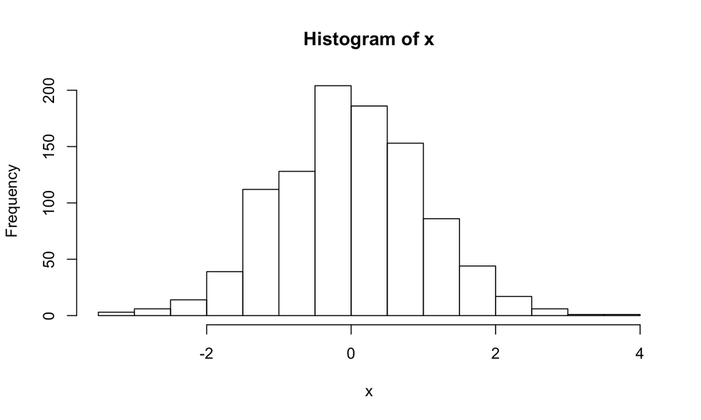

```r
x = rnorm(1000)
hist(x)
```

## Students t-distribution

```r
rn3 = sapply(1:100,function(x) return(mean(rnorm(3))))
rn20 = sapply(1:100,function(x) return(mean(rnorm(20))))
summary(rn3)
```

```
##     Min.  1st Qu.   Median     Mean  3rd Qu.     Max.
## -1.41218 -0.37018  0.02442  0.03388  0.40727  1.52630
```

```r
summary(rn20)
```

```
##     Min.  1st Qu.   Median     Mean  3rd Qu.     Max.
## -0.74535 -0.14405  0.01601  0.02086  0.18317  0.75792
```

## Students t-distribution

- Two distributions of the mean of our "population"
  - One with 20 samples
  - One with 3 samples

```r
plot(density(rn20),col='blue',xlim=c(-2,2))
lines(density(rn3),col='red')
```

## Students t-distribution

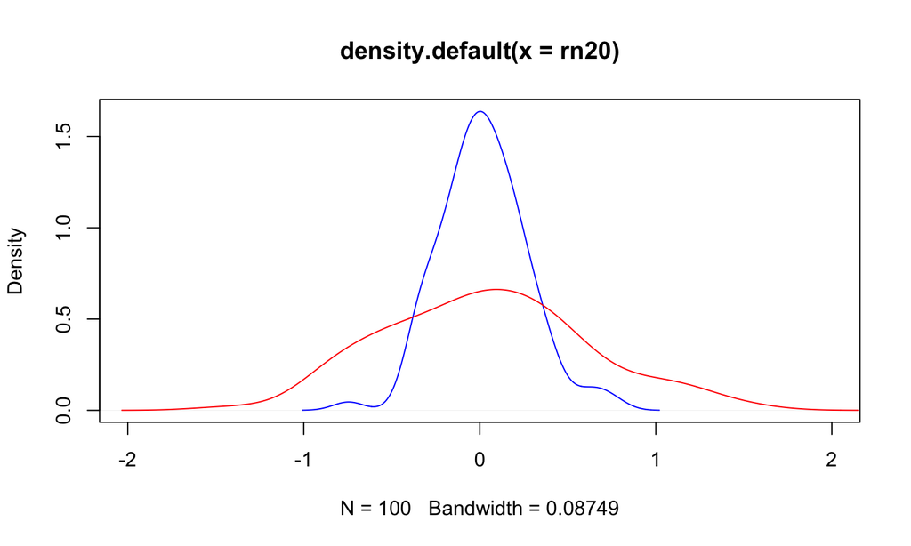

## Two groups – Population distribution

```r
g1 = rnorm(10000,1)
g2 = rnorm(10000,0)
```

```r
plot(density(g1),col='blue',xlim=c(-4,5))
lines(density(g2),col='red')
```

## Two groups – Population distribution

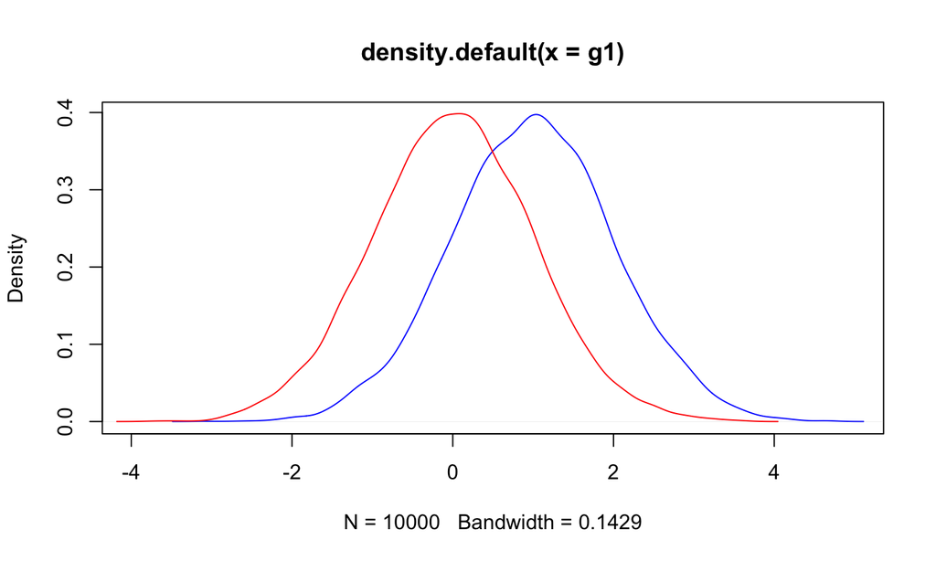

## Two groups – estimate of mean

What distribution do we use to estimate the mean?

```r
g1_3 = sapply(1:100,function(x) return(mean(rnorm(3))))
g2_3 = sapply(1:100,function(x) return(mean(rnorm(3,1))))
```

```r
g1_20 = sapply(1:100,function(x) return(mean(rnorm(20))))
g2_20 = sapply(1:100,function(x) return(mean(rnorm(20,1))))
```

## Two groups – estimate of mean

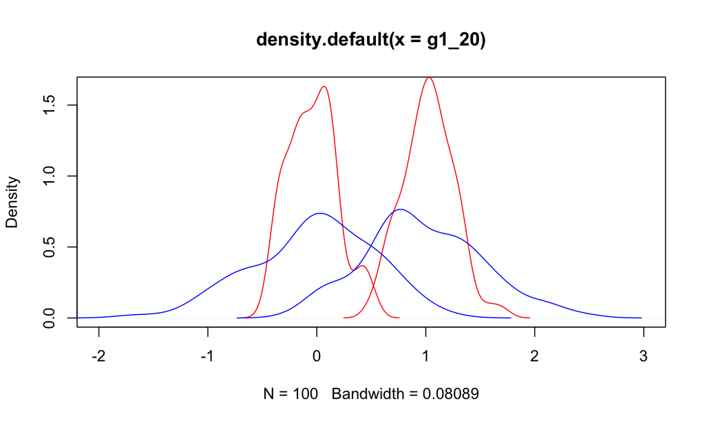

## Effects of population "spread" or standard devation

```r
g1 = rnorm(10000,1,2)
g2 = rnorm(10000,0,2)
```

```r
plot(density(g1),col='blue',xlim=c(-4,5))
lines(density(g2),col='red')
```

## Two groups – Population distribution

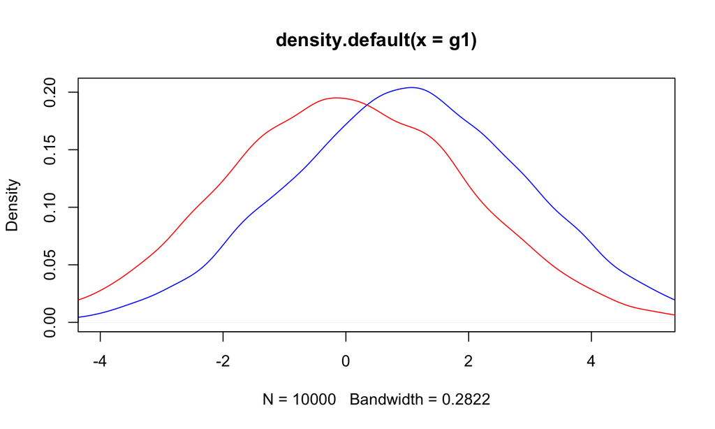

## Two groups – wider population spread

What distribution do we use to estimate the mean?

```r
g1_3 = sapply(1:100,function(x) return(mean(rnorm(3,0,2))))
g2_3 = sapply(1:100,function(x) return(mean(rnorm(3,1,2))))
```

```r
g1_20 = sapply(1:100,function(x) return(mean(rnorm(20,0,2))))
g2_20 = sapply(1:100,function(x) return(mean(rnorm(20,1,2))))
```

## Two groups – wider population spread

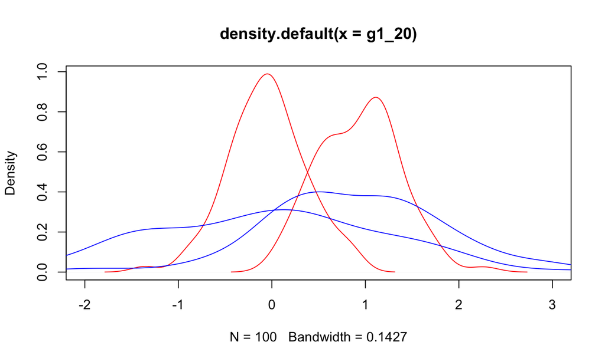

## Power

*Power* is the statistical probability that a test will reject the null hypothesis when the null hypothesis is *actually false*.

```r
install.packages('pwr')
# d is the "effect size"
pwr.t.test(n=10,d=1)
```

```
##
##      Two-sample t test power calculation
##
##               n = 10
##               d = 1
##       sig.level = 0.05
##           power = 0.5620066
##     alternative = two.sided
##
## NOTE: n is number in *each* group
```

## Basic Principles of Experimental Design

## Controls

## Replication

- Need estimates of centrality (mean) AND spread (variance)

## Randomization and Avoidance of Bias

- No batch effect

\[ y_i = \beta_1X_{1,i} + \epsilon\]

\(\beta_1\) is the estimate of the mean (or difference of means) of treatment.

- One "batch"

\[ y_i = \beta_1X_{1,i} + \beta_2X_{2,i} + \epsilon\]

\(\beta_1\) is the estimate of the mean (or difference of means) of treatment. \(\beta_2\) is the estimate of the mean of the batches.

## Randomization and Avoidance of Bias

```r
df = data.frame(expression=rnorm(12),
                treatment = rep(c(0,0,0,1,1,1),2),
                batch = c(rep(0,6),rep(1,6)))
df
```

```
##    expression treatment batch
## 1   0.3396697         0     0
## 2   0.1800823         0     0
## 3  -0.1329434         0     0
## 4   0.9089980         1     0
## 5   1.1466184         1     0
## 6   1.7553518         1     0
## 7   0.3178176         0     1
## 8  -0.5115211         0     1
## 9  -0.1879588         0     1
## 10 -0.4300730         1     1
## 11 -1.1551408         1     1
## 12  1.4119339         1     1
```

## Randomization and Avoidance of Bias

```r
df = data.frame(expression=rnorm(12),
                treatment = c(0,0,0,0,0,1,1,1,1,1,1,0),
                batch = c(rep(0,6),rep(1,6)))
df
```

```
##     expression treatment batch
## 1   0.98319365         0     0
## 2   1.16232115         0     0
## 3  -0.98826789         0     0
## 4   0.83557030         0     0
## 5  -1.22947508         0     0
## 6  -0.39994049         1     0
## 7   1.94756335         1     1
## 8   0.04623625         1     1
## 9   1.46517038         1     1
## 10  1.04777704         1     1
## 11 -0.73540825         1     1
## 12  0.18219965         0     1
```

## The Experimental Unit

(Fisher 1960) (Lazic 2010) pseudoreplication

## Design and Analysis

## *Know* how the results will be analyzed

## Signal/noise ratio

## Sources of variability and reducing them

## Blocking

## Quantify variability

- Population vs sample
- Standard Deviation
- Standard Error

## Generalizability

## References

Fisher, Ronald A. 1960. *The Design of Experiments / by Sir Ronald a. Fisher*. Book. 7th ed. Oliver & Boyd Edinburgh.

Fry, Derek J. 2014. “Teaching Experimental Design.” *ILAR Journal / National Research Council, Institute of Laboratory Animal Resources* 55 (3): 457–71. doi:10.1093/ilar/ilu031.

Lazic, Stanley E. 2010. “The Problem of Pseudoreplication in Neuroscientific Studies: Is It Affecting Your Analysis?” *BMC Neuroscience* 11 (1): 5. doi:10.1186/1471-2202-11-5.